# PREPROCESSING, KNN AND ASOCIATION RULE MINING ON BANK MARKETING

## I. MÔ TẢ VÀ DIỄN GIẢI DỮ LIỆU

### 1.1 Giới thiệu

Dữ liệu có liên quan đến các chiến dịch tiếp thị trực tiếp của một tổ chức ngân hang tại Bồ Đào Nha. Các chiến dịch tiếp thị này đều dựa trên các cuộc gọi điện thoại.

File dữ được dùng để xử lí, áp dụng thuật toán phân loại dữ liệu KNN và khai phá luật kết hợp: bank-additional-full.csv; gồm 41188 quan sát, 21 biến đầu vào.

### 1.2 Mô tả các biến

#### Các biến đặc trưng cá nhân của khách hàng

- **Age:** Độ tuổi của khách hàng.
- **Job:** Nghề nghiệp của khách hàng, bao gồm các loại sau:
  - admin.: Quản lý
  - blue collar: Công nhân
  - entrepreneur: Doanh nhân
  - housemaid: Giúp việc nhà
  - management: Quản lý
  - retired: Nghỉ hưu
  - self-employed: Tự do
  - services: Dịch vụ
  - student: Học sinh
  - technician: Kỹ thuật viên
  - unemployed: Thất nghiệp
  - unknown: Không rõ
- **Marital:** Tình trạng hôn nhân của khách hàng, bao gồm các loại sau:
  - divorced: Ly hôn
  - married: Đã kết hôn
  - single: Độc thân
  - unknown: Không rõ
- **Education:** Trình độ học vấn của khách hàng, bao gồm các loại sau:
  - basic.4y
  - basic.6y
  - basic.9y
  - high.school: Học hết cấp 3
  - illiterate: Không biết chữ
  - professional.course: Học nghề
  - university.degree: Đại học
  - unknown: Không rõ

#### Các biến về lịch sử tín dụng của khách hàng

- **default:** Có nợ xấu không, có thể là “yes” hoặc “no”.
- **housing:** Có vay mua nhà không, có thể là “yes” hoặc “no”.
- **loan:** Có vay tín dụng cá nhân không, có thể là “yes” hoặc “no”.

#### Các biến về chiến dịch tiếp thị

- **Contact:** Loại hình liên hệ với khách hàng, có thể là “cellular” (gọi điện thoại di động) hoặc “telephone” (gọi điện thoại bàn).
- **day_of_week:** Ngày liên hệ cuối cùng trong tuần, có thể là “fri” (thứ sáu), “mon” (thứ hai), “thu” (thứ năm), “tue” (thứ ba), “wed” (thứ tư).
- **Month:** Tháng liên hệ cuối cùng trong năm, có thể là “jan” (tháng 1), “feb” (tháng 2), “mar” (tháng 3), ..., “nov” (tháng 11), “dec” (tháng 12).
- **Duration:** Thời lượng của cuộc liên hệ cuối cùng, tính bằng giây.
- **campaign:** Số lần liên hệ được thực hiện trong chiến dịch này và với khách hàng này (bao gồm liên hệ cuối cùng).
- **pdays:** Số ngày đã trôi qua kể từ lần khách hàng được liên hệ lần cuối từ một chiến dịch trước đó (999 nghĩa là khách hàng chưa được liên hệ trước đó).
- **previous:** Số lượng liên hệ được thực hiện từ các chiến dịch trước và cho khách hàng này.
- **poutcome:** Kết quả của chiến dịch tiếp thị trước đó, có thể là “failure” (không thành công), “nonexistent” (chưa được liên hệ trước đó) hoặc “success” (thành công).

#### Biến mục tiêu

- **y:** Khách hàng có đăng ký gửi tiết kiệm/gửi có kì hạn không, có thể là “no” hoặc “yes”.

#### Các biến bổ sung liên quan đến bối cảnh kinh tế xã hội

- **emp.var.rate:** Tỷ lệ biến động việc làm - chỉ số hàng quý.
- **cons.conf.idx:** Chỉ số niềm tin người tiêu dùng - chỉ số hàng tháng.
- **Cons.price.idx:** Chỉ số giá tiêu dùng - chỉ số hàng tháng (số).
- **euribor3m:** Lãi suất Euribor 3 tháng - chỉ số hàng ngày.
- **nr.employed:** Số lượng nhân viên - chỉ số hàng quý.

### 1.3 Nguồn dữ liệu

Dữ liệu được lấy từ Kho lưu trữ máy học của Đại học California

Link: https://archive.ics.uci.edu/dataset/222/bank+marketing

## II. TIỀN XỬ LÝ DỮ LIỆU

**Gọi gói**

```r
library(tidyr)
library(janitor) #kiểm tra dữ liệu trùng lặp
library(dplyr)
library(tables)
```

**Đọc file dữ liệu**

```r
bm <- read.csv("G:\\My Drive\\4 Senior\\Data mining\\bank+marketing\\bank-additional-full.csv", sep=";")
str(bm)
```

```
## 'data.frame':    41188 obs. of  21 variables:
##  $ age           : int  56 57 37 40 56 45 59 41 24 25 ...
##  $ job           : chr  "housemaid" "services" "services" "admin." ...
##  $ marital       : chr  "married" "married" "married" "married" ...
##  $ education     : chr  "basic.4y" "high.school" "high.school" "basic.6y" ...
##  $ default       : chr  "no" "unknown" "no" "no" ...
##  $ housing       : chr  "no" "no" "yes" "no" ...
##  $ loan          : chr  "no" "no" "no" "no" ...
##  $ contact       : chr  "telephone" "telephone" "telephone" "telephone" ...
##  $ month         : chr  "may" "may" "may" "may" ...
##  $ day_of_week   : chr  "mon" "mon" "mon" "mon" ...
##  $ duration      : int  261 149 226 151 307 198 139 217 380 50 ...
##  $ campaign      : int  1 1 1 1 1 1 1 1 1 1 ...
##  $ pdays         : int  999 999 999 999 999 999 999 999 999 999 ...
##  $ previous      : int  0 0 0 0 0 0 0 0 0 0 ...
##  $ poutcome      : chr  "nonexistent" "nonexistent" "nonexistent" "nonexistent" ...
##  $ emp.var.rate  : num  1.1 1.1 1.1 1.1 1.1 1.1 1.1 1.1 1.1 1.1 ...
##  $ cons.price.idx: num  94 94 94 94 94 ...
##  $ cons.conf.idx : num  -36.4 -36.4 -36.4 -36.4 -36.4 -36.4 -36.4 -36.4 -36.4 -36.4 ...
##  $ euribor3m     : num  4.86 4.86 4.86 4.86 4.86 ...
##  $ nr.employed   : num  5191 5191 5191 5191 5191 ...
##  $ y             : chr  "no" "no" "no" "no" ...
```

**Kiểm tra trùng lặp trong dữ liệu**

```r
get_dupes(bm)
```

```
## No variable names specified - using all columns.
```

| age | job | marital | education | default | housing | loan | contact | month | day_of_week | duration | campaign | pdays | previous | poutcome | emp.var.rate | cons.price.idx | cons.conf.idx | euribor3m | nr.employed | y | dupe_count |
| --- | --- | --- | --- | --- | --- | --- | --- | --- | --- | --- | --- | --- | --- | --- | --- | --- | --- | --- | --- | --- | --- |
| 24 | services | single | high.school | no | yes | no | cellular | apr | tue | 114 | 1 | 999 | 0 | nonexistent | -1.8 | 93.075 | -47.1 | 1.423 | 5099.1 | no | 2 |
| 24 | services | single | high.school | no | yes | no | cellular | apr | tue | 114 | 1 | 999 | 0 | nonexistent | -1.8 | 93.075 | -47.1 | 1.423 | 5099.1 | no | 2 |
| 27 | technician | single | professional.course | no | no | no | cellular | jul | mon | 331 | 2 | 999 | 0 | nonexistent | 1.4 | 93.918 | -42.7 | 4.962 | 5228.1 | no | 2 |
| 27 | technician | single | professional.course | no | no | no | cellular | jul | mon | 331 | 2 | 999 | 0 | nonexistent | 1.4 | 93.918 | -42.7 | 4.962 | 5228.1 | no | 2 |
| 32 | technician | single | professional.course | no | yes | no | cellular | jul | thu | 128 | 1 | 999 | 0 | nonexistent | 1.4 | 93.918 | -42.7 | 4.968 | 5228.1 | no | 2 |
| 32 | technician | single | professional.course | no | yes | no | cellular | jul | thu | 128 | 1 | 999 | 0 | nonexistent | 1.4 | 93.918 | -42.7 | 4.968 | 5228.1 | no | 2 |
| 35 | admin. | married | university.degree | no | yes | no | cellular | may | fri | 348 | 4 | 999 | 0 | nonexistent | -1.8 | 92.893 | -46.2 | 1.313 | 5099.1 | no | 2 |
| 35 | admin. | married | university.degree | no | yes | no | cellular | may | fri | 348 | 4 | 999 | 0 | nonexistent | -1.8 | 92.893 | -46.2 | 1.313 | 5099.1 | no | 2 |
| 36 | retired | married | unknown | no | no | no | telephone | jul | thu | 88 | 1 | 999 | 0 | nonexistent | 1.4 | 93.918 | -42.7 | 4.966 | 5228.1 | no | 2 |
| 36 | retired | married | unknown | no | no | no | telephone | jul | thu | 88 | 1 | 999 | 0 | nonexistent | 1.4 | 93.918 | -42.7 | 4.966 | 5228.1 | no | 2 |

[output cut: 14 more lines]

```r
bm_new <- unique(bm)
```

Từ kết quả, ta thấy có 24 quan sát có sự trùng lặp ở tất cả các biến, vì vậy ta cần loại bỏ dữ liệu trùng lặp. Sau khi loại bỏ, dữ liệu bm_new không có trùng lặp, bao gồm 41176 quan sát và 21 biến.

**Kiểm tra dữ liệu khuyết thiếu**

```r
sum(is.na(bm_new))
```

```
## [1] 0
```

=> Kết quả cho thấy bộ dữ liệu không có missing.

**Loại bỏ 5 biến liên quan đến bối cảnh kinh tế xã hội**

```r
bm_new <- bm_new[, -c(16,17,18,19,20)]
```

**Thống kê mô tả các biến**

```r
summary(bm_new)
```

```
##       age            job              marital           education
##  Min.   :17.00   Length:41176       Length:41176       Length:41176
##  1st Qu.:32.00   Class :character   Class :character   Class :character
##  Median :38.00   Mode  :character   Mode  :character   Mode  :character
##  Mean   :40.02
##  3rd Qu.:47.00
##  Max.   :98.00
##    default            housing              loan             contact
##  Length:41176       Length:41176       Length:41176       Length:41176
##  Class :character   Class :character   Class :character   Class :character
##  Mode  :character   Mode  :character   Mode  :character   Mode  :character
##
##
##
##     month           day_of_week           duration         campaign
##  Length:41176       Length:41176       Min.   :   0.0   Min.   : 1.000
##  Class :character   Class :character   1st Qu.: 102.0   1st Qu.: 1.000
##  Mode  :character   Mode  :character   Median : 180.0   Median : 2.000
##                                        Mean   : 258.3   Mean   : 2.568
##                                        3rd Qu.: 319.0   3rd Qu.: 3.000
##                                        Max.   :4918.0   Max.   :56.000
##      pdays          previous       poutcome              y
##  Min.   :  0.0   Min.   :0.000   Length:41176       Length:41176
##  1st Qu.:999.0   1st Qu.:0.000   Class :character   Class :character
##  Median :999.0   Median :0.000   Mode  :character   Mode  :character
##  Mean   :962.5   Mean   :0.173
##  3rd Qu.:999.0   3rd Qu.:0.000
##  Max.   :999.0   Max.   :7.000
```

**Kiểm tra dữ liệu đột xuất cho các biến định lượng**

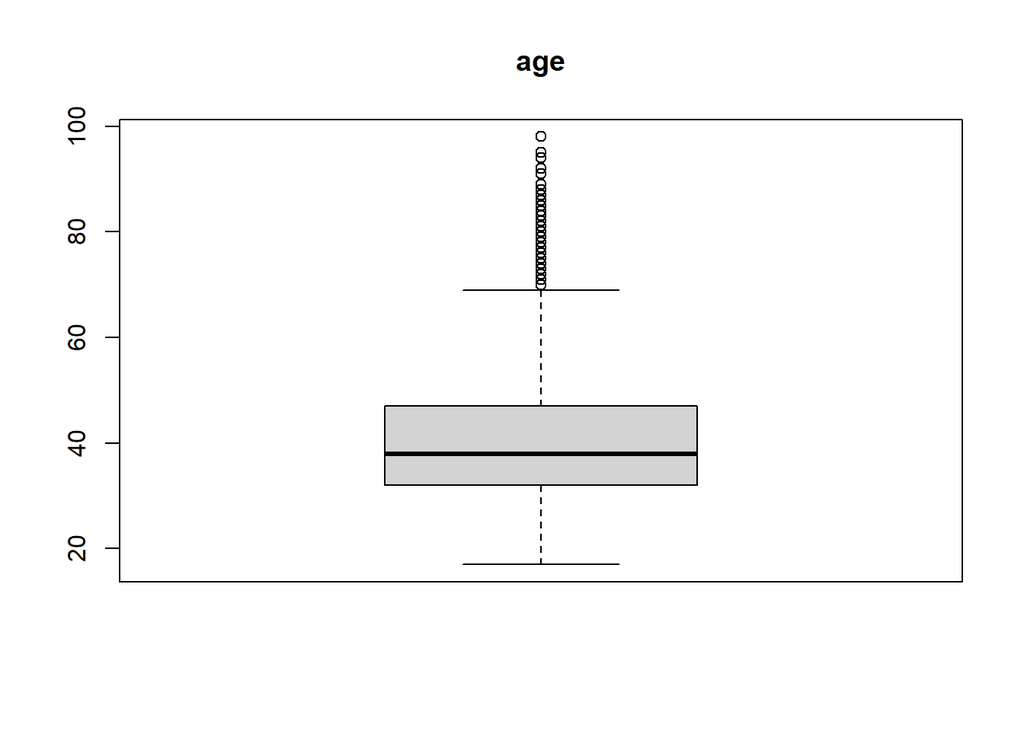

```r
boxplot(bm_new$age, main = "age")
```

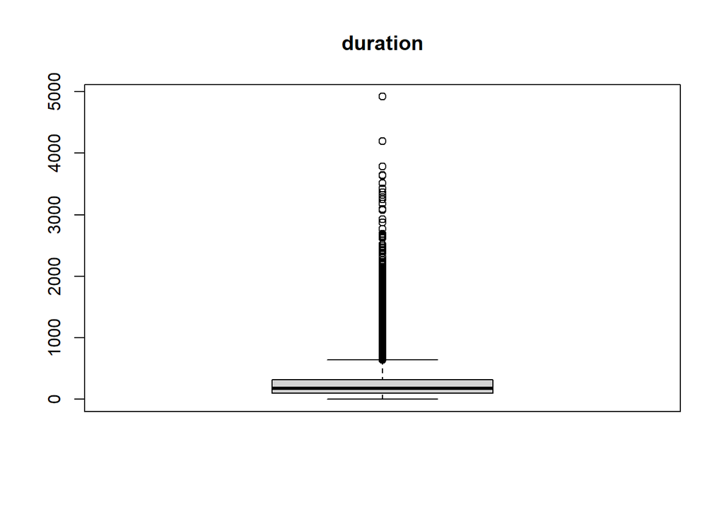

```r
boxplot(bm_new$duration, main = "duration")
```

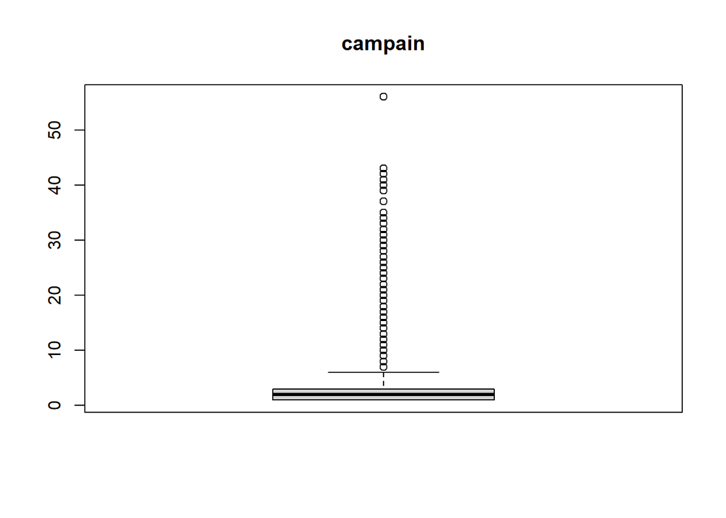

```r
boxplot(bm_new$campaign, main = "campain")
```

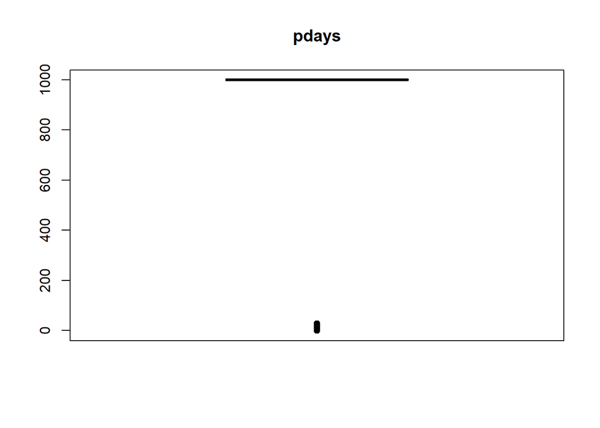

```r
boxplot(bm_new$pdays, main = "pdays")
```

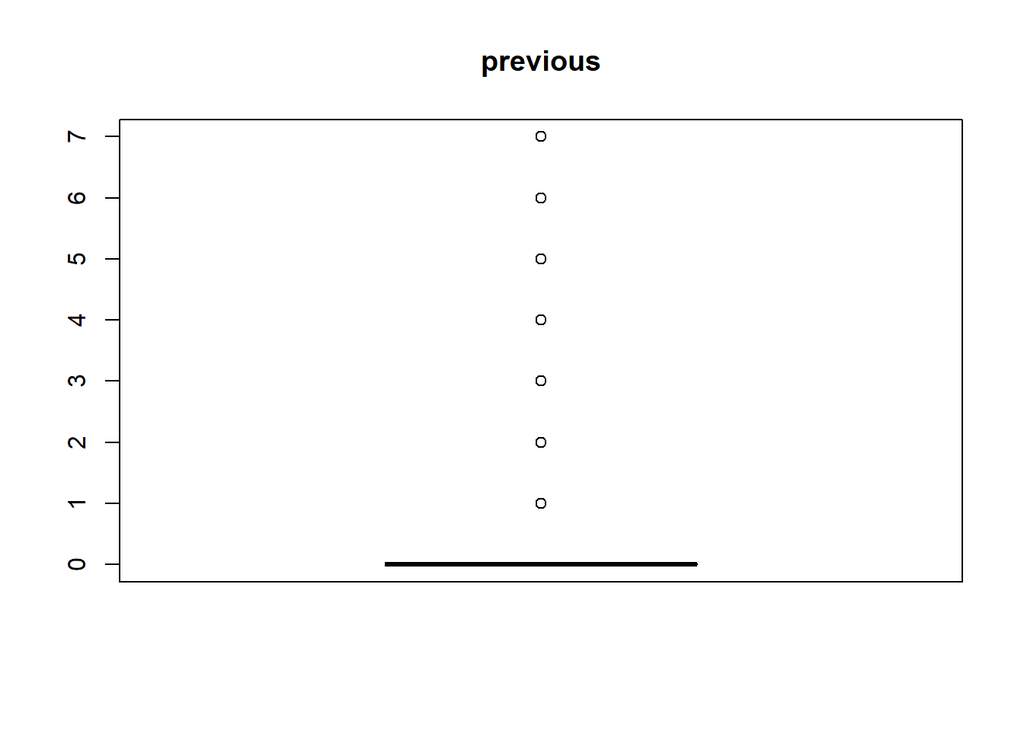

```r
boxplot(bm_new$previous, main = "previous")
```

Dựa vào đồ thị boxplt, ta thấy 5 biến: age, duration, campain, pdays, previous đều có outlier (nằm ngoài khoảng [q3-1.5IQR; q3+1.5IQR])

Vì vậy, ta tiến hành thay thế các outlies theo quy tắc:

- Giá trị ở phía trên được thay thế bằng Q3+1.5IQR.

- Giá trị ở phía dưới được thay thế bằng Q1-1.5IQR.

- **Với biến age:**

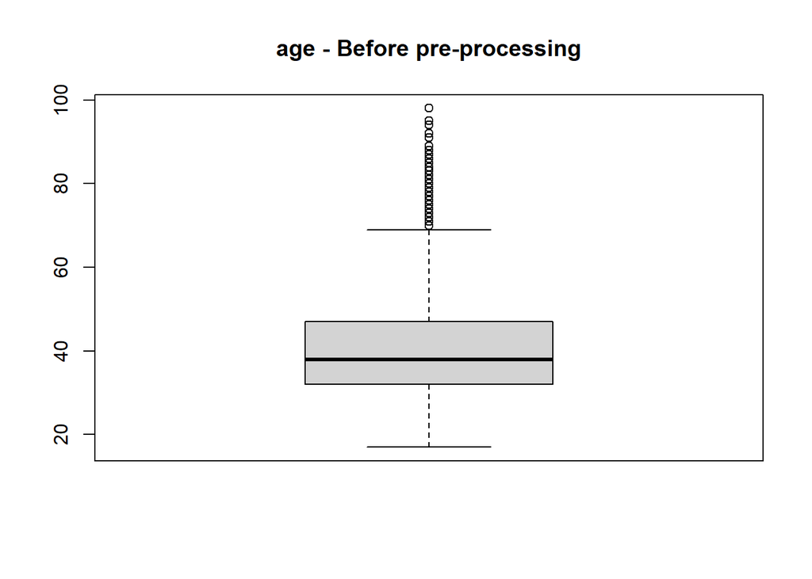

```r
iqr <-  as.numeric(IQR(bm_new$age))
q3 <-  as.numeric(quantile(bm_new$age,0.75))
q1 <-  as.numeric(quantile(bm_new$age,0.25))
upper = (q3 + 1.5*iqr)
lower = (q1 - 1.5*iqr)
bm_new$age[bm_new$age>upper] = upper
bm_new$age[bm_new$age<lower] = lower
boxplot(bm$age,main=paste('age - Before pre-processing'))
```

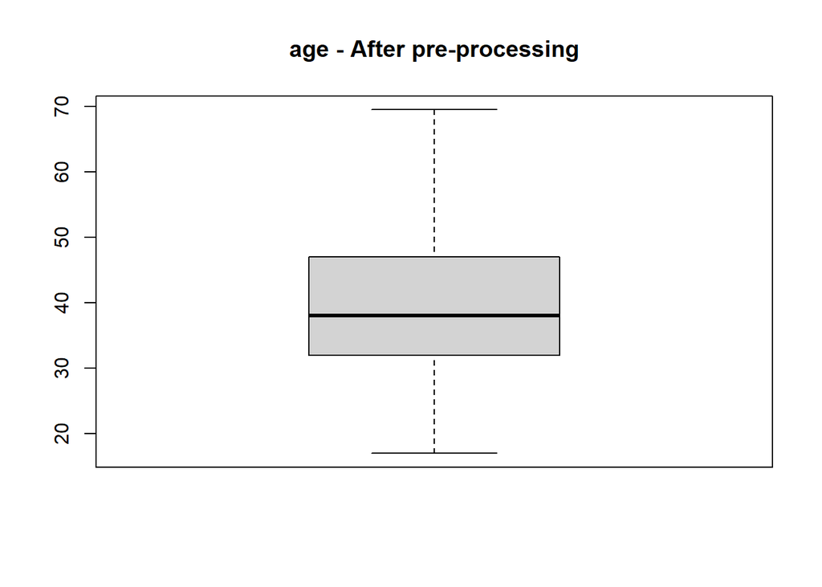

```r
boxplot(bm_new$age,main=paste('age - After pre-processing'))
```

- **Với biến duration:**

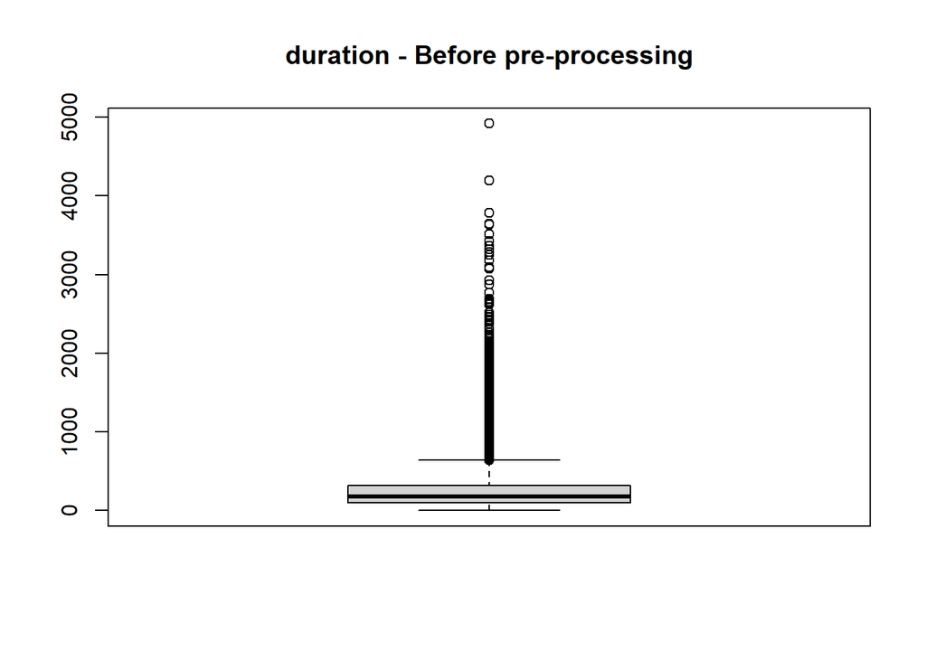

```r
iqr <-  as.numeric(IQR(bm_new$duration))
q3 <-  as.numeric(quantile(bm_new$duration,0.75))
q1 <-  as.numeric(quantile(bm_new$duration,0.25))
upper = (q3 + 1.5*iqr)
lower = (q1 - 1.5*iqr)
bm_new$duration[bm_new$duration>upper] = upper
bm_new$duration[bm_new$duration<lower] = lower
boxplot(bm$duration,main=paste('duration - Before pre-processing'))
```

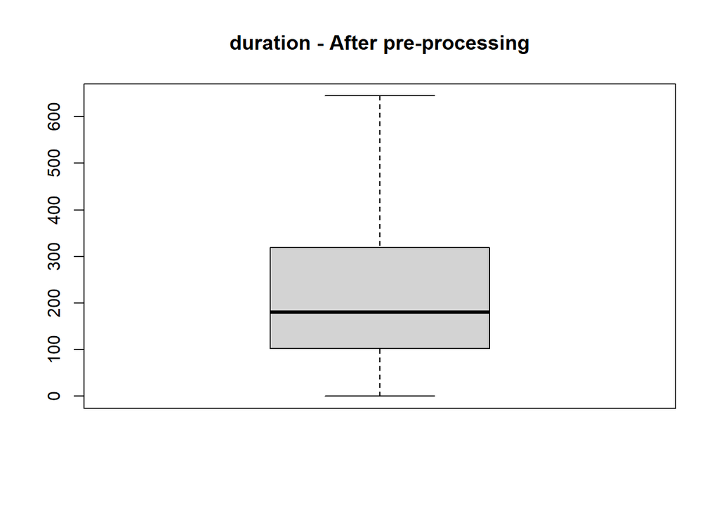

```r
boxplot(bm_new$duration,main=paste('duration - After pre-processing'))
```

- **Với biến campaign:**

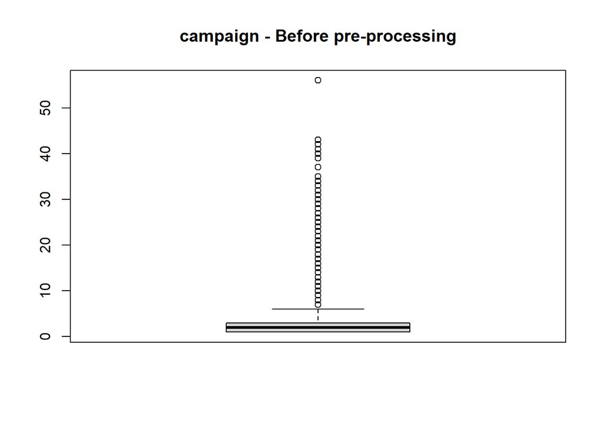

```r
iqr <-  as.numeric(IQR(bm_new$campaign))
q3 <-  as.numeric(quantile(bm_new$campaign,0.75))
q1 <-  as.numeric(quantile(bm_new$campaign,0.25))
upper = (q3 + 1.5*iqr)
lower = (q1 - 1.5*iqr)
bm_new$campaign[bm_new$campaign>upper] = upper
bm_new$campaign[bm_new$campaign<lower] = lower
boxplot(bm$campaign,main=paste('campaign - Before pre-processing'))
```

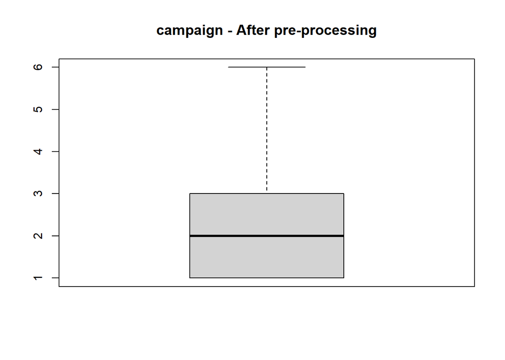

```r
boxplot(bm_new$campaign,main=paste('campaign - After pre-processing'))
```

- **Với biến pdays:**

  Trước hết ta tạo bảng tần số và tần suất

```r
round(prop.table(table(bm$pdays)),3)
```

```
##
##     0     1     2     3     4     5     6     7     8     9    10    11    12
## 0.000 0.001 0.001 0.011 0.003 0.001 0.010 0.001 0.000 0.002 0.001 0.001 0.001
##    13    14    15    16    17    18    19    20    21    22    25    26    27
## 0.001 0.000 0.001 0.000 0.000 0.000 0.000 0.000 0.000 0.000 0.000 0.000 0.000
##   999
## 0.963
```

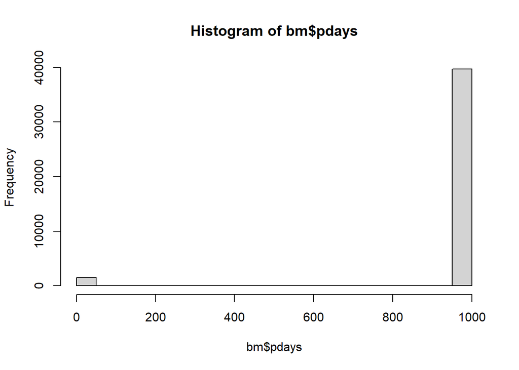

```r
hist(bm$pdays)
```

- Từ bảng trên và đồ thị boxplot, ta thấy rằng, các giá trị từ 1 đến 27 chỉ chiếm 3.8 %, đồng thời, tất cả các giá trị này đều là các outlier. Tuy nhiên:
- Con số 999 chỉ biểu thị các trường hợp khách hàng chưa từng được gọi điện, chứ không phải “đã trôi qua 999 ngày kể từ lần cuối khách hàng được liên hệ”, do đó con số này không có ý nghĩa toán học.
- Bên cạnh đó, các outlier này có thể là dữ liệu thực tế. Nếu loại bỏ các outlier này, ta sẽ mất đi một phần dữ liệu thực tế. Về mặt ý nghĩa, việc tập khách hàng của 1 ngân hàng mà không bao gồm khách hàng cũ (khách hàng đã được liên hệ ở chiến dịch marketing trước) là điều khó xảy ra.
- **Với biến previous:** (số lượng liên hệ được thực hiện từ các chiến dịch trước và cho khách hàng này)

```r
round(prop.table(table(bm$previous)),3)
```

```
##
##     0     1     2     3     4     5     6     7
## 0.863 0.111 0.018 0.005 0.002 0.000 0.000 0.000
```

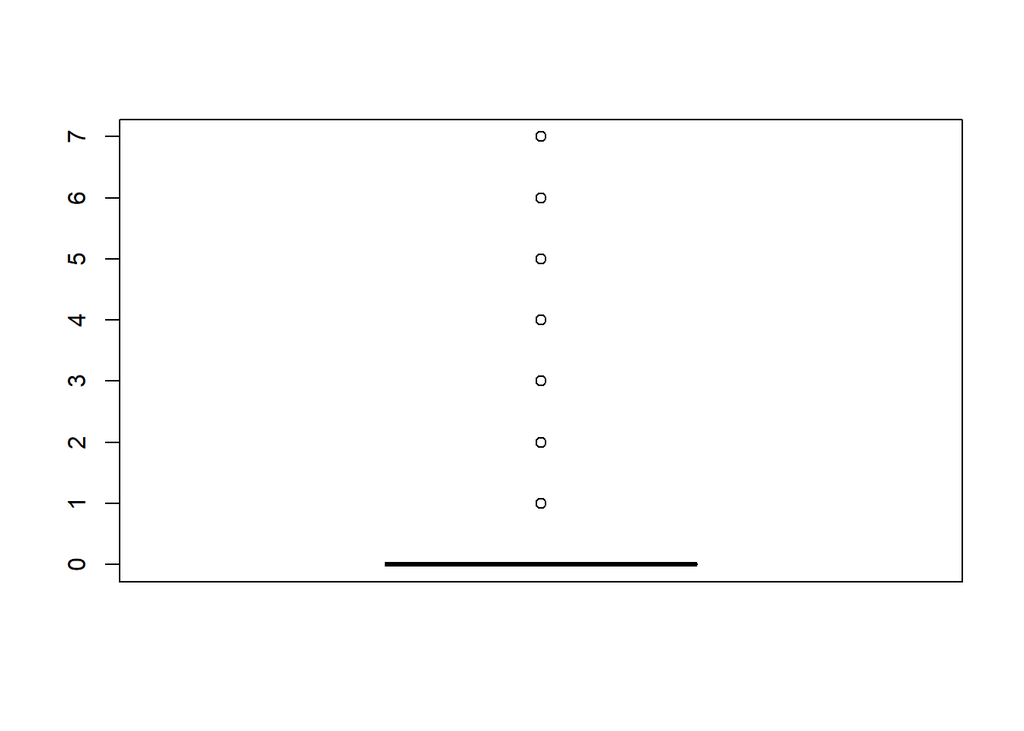

```r
boxplot(bm$previous)
```

```r
summary(bm$previous)
```

```
##    Min. 1st Qu.  Median    Mean 3rd Qu.    Max.
##   0.000   0.000   0.000   0.173   0.000   7.000
```

- Từ bảng tần số, bảng thống kê mô tả và biểu đồ, ta thấy các outlier là các quan sát có giá trị previous là 1,2,3,4,5,6,7.
- Nếu xóa bỏ thì cột này chỉ còn giá trị 0, điều này làm cho cột previous vô nghĩa và mất đi một phần dữ liệu thực tế.
- Nếu thay thế bằng mode, median hay mean, q1, q3 thì cũng không hợp lí.
- Về mặt ý nghĩa, việc khách hàng đã tham gia chiến dịch marketing lần trước hoàn toàn có khả năng tham gia vào chiến dịch sau, nên việc các liên hệ được thực hiện với số lần lớn hơn 0 là điều bình thường. Vì vậy nhóm quyết định giữ nguyên các giá trị này.

## III. ÁP DỤNG K-NEAREST NEIGHBOR (KNN)

- **Gọi gói**

```r
library(ggplot2)
library(dplyr)
library(caret)
library(class) #KNN
```

### 3.1 Tiền xử lý

- **Chuyển một** **số biến sang kiểu dữ liệu Factor**

```r
bm_knn <- bm_new
cols <- c("job", "marital", "education", "default", "housing", "loan", "contact", "month", "day_of_week", "poutcome", "y", "previous")

for (col in cols) {
  bm_knn[, col] <- as.factor(bm_knn[, col])
  }
str(bm_knn)
```

```
## 'data.frame':    41176 obs. of  16 variables:
##  $ age        : num  56 57 37 40 56 45 59 41 24 25 ...
##  $ job        : Factor w/ 12 levels "admin.","blue-collar",..: 4 8 8 1 8 8 1 2 10 8 ...
##  $ marital    : Factor w/ 4 levels "divorced","married",..: 2 2 2 2 2 2 2 2 3 3 ...
##  $ education  : Factor w/ 8 levels "basic.4y","basic.6y",..: 1 4 4 2 4 3 6 8 6 4 ...
##  $ default    : Factor w/ 3 levels "no","unknown",..: 1 2 1 1 1 2 1 2 1 1 ...
##  $ housing    : Factor w/ 3 levels "no","unknown",..: 1 1 3 1 1 1 1 1 3 3 ...
##  $ loan       : Factor w/ 3 levels "no","unknown",..: 1 1 1 1 3 1 1 1 1 1 ...
##  $ contact    : Factor w/ 2 levels "cellular","telephone": 2 2 2 2 2 2 2 2 2 2 ...
##  $ month      : Factor w/ 10 levels "apr","aug","dec",..: 7 7 7 7 7 7 7 7 7 7 ...
##  $ day_of_week: Factor w/ 5 levels "fri","mon","thu",..: 2 2 2 2 2 2 2 2 2 2 ...
##  $ duration   : num  261 149 226 151 307 198 139 217 380 50 ...
##  $ campaign   : num  1 1 1 1 1 1 1 1 1 1 ...
##  $ pdays      : int  999 999 999 999 999 999 999 999 999 999 ...
##  $ previous   : Factor w/ 8 levels "0","1","2","3",..: 1 1 1 1 1 1 1 1 1 1 ...
##  $ poutcome   : Factor w/ 3 levels "failure","nonexistent",..: 2 2 2 2 2 2 2 2 2 2 ...
##  $ y          : Factor w/ 2 levels "no","yes": 1 1 1 1 1 1 1 1 1 1 ...
```

- **Phân loại các giá trị trong biến ‘pdays’ thành hai nhóm**

- Nếu giá trị của biến pdays nhỏ hơn hoặc bằng 200, thì sẽ được phân vào nhóm priorContact: đã được liên hệ từ chiến dịch lần trước.

- Nếu giá trị của biến pdays lớn hơn 200, thì sẽ được phân vào nhóm NoPriorContact : chưa được liên hệ từ chiến dịch marketing trước đây.

```r
bm_knn$pdays <- cut(bm_knn$pdays, breaks= c(0,200,Inf), labels= c('Đã liên hệ từ chiến dịch trước','Chưa từng liên hệ'), include.lowest = TRUE)
table(bm_knn$pdays)
```

```
##
## Đã liên hệ từ chiến dịch trước              Chưa từng liên hệ
##                           1515                          39661
```

```r
cols <- c("job", "marital", "education", "default", "housing", "loan", "contact", "month", "day_of_week", "poutcome", "previous", "pdays")

for (col in cols) {
  bm_knn[, col] <- as.numeric(bm_knn[, col])
  }
```

- **Chuẩn hóa các biến định lượng**

```r
bm_knn[,c(1,11,12)] <- scale(bm_knn[,c(1,11,12)], center = TRUE, scale = TRUE)
```

- **Phân tách tập dữ liệu thành dữ liệu huấn luyện (Train) và dữ liệu kiểm tra (Test)**

- Tạo vector index training gồm 70% quan sát được chọn ngẫu nhiên từ dataframe bm_knn

- Tạo dataframe training_set trên cơ sở lấy các quan sát theo thứ tự như vector training vừa tạo, bao gồm 28824 quan sát với 16 biến.

- Tạo dataframe test_set bao gồm 12352 quan sát còn lại với 16 biến.

```r
# Tạo phân vùng dữ liệu
training <- createDataPartition(bm_knn$y, p = 0.7, list = FALSE)

# Chia dữ liệu thành hai tập
training_set <-  slice(bm_knn, training)
test_set <- slice(bm_knn, - training)
```

- **Tạo dataframe chứa các biến thuộc tính trong các tập dữ liệu đã tạo**

```r
x_train <- select(training_set, - y)
x_test <- select(test_set, - y)
```

- **Tạo các giá trị riêng cho biến mục tiêu**

```r
y_train <- training_set$y
y_test <- test_set$y
```

### **3.2 Huấn luyện mô hình**

- **Chạy KNN**

  Thuật toán phân loại knn đối với các thuộc tính của tập huấn luyện x_train , tập kiểm tra x_test , biến mục tiêu của tập huấn luyện y_train và k = 99

```r
model_knn <- knn(train=x_train,
    test=x_test,
    cl=y_train,
    k=99)
```

- **Lựa chọn k tốt nhất**

Xác định các tham số kiểm soát cho quá trình huấn luyện bằng phương pháp cross-validation.

Sau đó huấn luyện một mô hình KNN sử dụng tập dữ liệu training_set và các tham số kiểm soát (ctrl).

Chọn tham số tuneLength (30) xác định số lần mô hình được huấn luyện với các giá trị tham số khác nhau để tìm giá trị tối ưu.

```r
ctrl <- trainControl(method = "cv", number = 4)
best_knn <- train(y~.,training_set, method = "knn", trControl = ctrl,tuneLength = 30)
best_knn
```

```
## k-Nearest Neighbors
##
## 28824 samples
##    15 predictor
##     2 classes: 'no', 'yes'
##
## No pre-processing
## Resampling: Cross-Validated (4 fold)
## Summary of sample sizes: 21618, 21618, 21618, 21618
## Resampling results across tuning parameters:
##
##   k   Accuracy   Kappa
##    5  0.8912712  0.27335711
##    7  0.8940813  0.25871443
##    9  0.8943936  0.23468490
```

[output cut: 30 more lines]

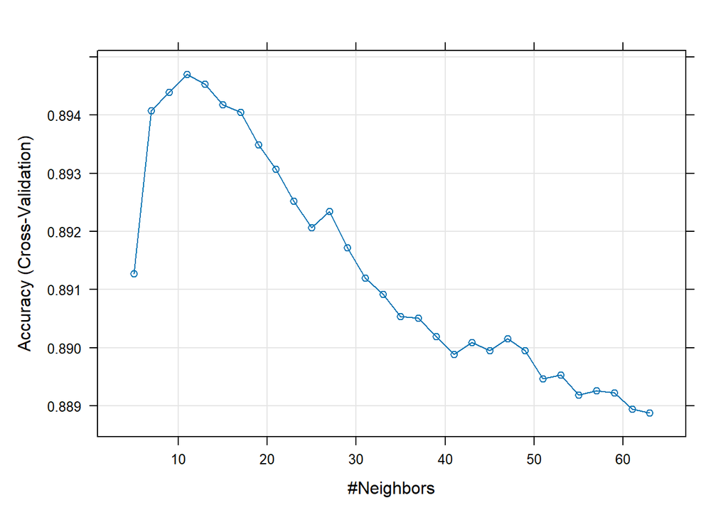

```r
plot(best_knn)
```

- **Dự đoán tập test_set**

Dựa vào kết quả k tốt nhất đã xác định, cho kết quả dự đoán dựa vào giá trị k xác định được từ best_knn trên cơ sở tập dữ liệu kiểm tra test_set

```r
pred <- predict(best_knn, test_set)
```

### **3.3 Đánh giá mô hình**

```r
mean(pred == y_test)
```

```
## [1] 0.8936205
```

```r
confusionMatrix(table(y_test, pred))
```

```
## Confusion Matrix and Statistics
##
##       pred
## y_test    no   yes
##    no  10819   142
##    yes  1172   219
##
##                Accuracy : 0.8936
##                  95% CI : (0.888, 0.899)
##     No Information Rate : 0.9708
##     P-Value [Acc > NIR] : 1
##
##                   Kappa : 0.2135
##
##  Mcnemar's Test P-Value : <2e-16
##
##             Sensitivity : 0.9023
##             Specificity : 0.6066
##          Pos Pred Value : 0.9870
##          Neg Pred Value : 0.1574
##              Prevalence : 0.9708
##          Detection Rate : 0.8759
##    Detection Prevalence : 0.8874
##       Balanced Accuracy : 0.7545
##
##        'Positive' Class : no
##
```

- Giá trị dự đoán âm này cho thấy mô hình KNN dự đoán sai khá nhiều lớp của các điểm dữ liệu thuộc lớp “yes”. Nguyên nhân có thể là do: Tập dữ liệu huấn luyện không cân bằng. Trong trường hợp này, số lượng điểm dữ liệu thuộc lớp “yes” ít hơn rất nhiều so với số lượng điểm dữ liệu thuộc lớp “no”. Điều này khiến mô hình KNN có xu hướng dự đoán lớp “no” cho nhiều điểm dữ liệu.

## IV. KHAI PHÁ QUY LUẬT KẾT HỢP

### 4.1 Tiền xử lý

- **Gọi gói**

```r
library(ggplot2)
library(tidyverse)
library(cluster)
library(arules)
library(arulesViz)
```

- **Chuyển một số biến sang kiểu dữ liệu Factor**

```r
bm_ar <- bm_new
cols <- c("job", "marital", "education", "default", "housing", "loan", "contact", "month", "day_of_week", "poutcome", "y", "previous")

for (col in cols) {
  bm_ar[, col] <- as.factor(bm_ar[, col])
  }
str(bm_ar)
```

```
## 'data.frame':    41176 obs. of  16 variables:
##  $ age        : num  56 57 37 40 56 45 59 41 24 25 ...
##  $ job        : Factor w/ 12 levels "admin.","blue-collar",..: 4 8 8 1 8 8 1 2 10 8 ...
##  $ marital    : Factor w/ 4 levels "divorced","married",..: 2 2 2 2 2 2 2 2 3 3 ...
##  $ education  : Factor w/ 8 levels "basic.4y","basic.6y",..: 1 4 4 2 4 3 6 8 6 4 ...
##  $ default    : Factor w/ 3 levels "no","unknown",..: 1 2 1 1 1 2 1 2 1 1 ...
##  $ housing    : Factor w/ 3 levels "no","unknown",..: 1 1 3 1 1 1 1 1 3 3 ...
##  $ loan       : Factor w/ 3 levels "no","unknown",..: 1 1 1 1 3 1 1 1 1 1 ...
##  $ contact    : Factor w/ 2 levels "cellular","telephone": 2 2 2 2 2 2 2 2 2 2 ...
##  $ month      : Factor w/ 10 levels "apr","aug","dec",..: 7 7 7 7 7 7 7 7 7 7 ...
##  $ day_of_week: Factor w/ 5 levels "fri","mon","thu",..: 2 2 2 2 2 2 2 2 2 2 ...
##  $ duration   : num  261 149 226 151 307 198 139 217 380 50 ...
##  $ campaign   : num  1 1 1 1 1 1 1 1 1 1 ...
##  $ pdays      : int  999 999 999 999 999 999 999 999 999 999 ...
##  $ previous   : Factor w/ 8 levels "0","1","2","3",..: 1 1 1 1 1 1 1 1 1 1 ...
##  $ poutcome   : Factor w/ 3 levels "failure","nonexistent",..: 2 2 2 2 2 2 2 2 2 2 ...
##  $ y          : Factor w/ 2 levels "no","yes": 1 1 1 1 1 1 1 1 1 1 ...
```

```r
bm_ar$age <- cut(bm_ar$age, breaks=c(12,30,50,Inf), labels=c('Người trẻ','Trung niên','Cao niên'))
table(bm_ar$age)
```

```
##
##  Người trẻ Trung niên   Cao niên
##       7381      26617       7178
```

- **Tạo ra 3 tổ bằng nhau cho biến ‘duration’**:
  - Tìm giá trị lớn nhất và nhỏ nhất của biến duration
  - Sử dụng hàm cut() để phân tổ với tham số include.lowest = TRUE.
  - Note: Hàm seq() tạo một chuỗi các số bắt đầu từ giá trị nhỏ nhất của biến duration, kết thúc ở giá trị lớn nhất, và tăng dần theo khoảng cách tổ

```r
max_duration <- max(bm_ar$duration)
min_duration <- min(bm_ar$duration)
width <- (max_duration - min_duration)/3
bm_ar$duration <- cut(bm_ar$duration, breaks = seq(min_duration, max_duration, width), include.lowest = TRUE)
table(bm_ar$duration)
```

```
##
##   [0,215] (215,430] (430,644]
##     24100     10676      6400
```

- **Tạo ra 3 tổ bằng nhau cho biến ‘campain’:**

```r
min_campaign <- min(bm_ar$campaign)
max_campaign <- max(bm_ar$campaign)
width <- (max_campaign - min_campaign)/3

bm_ar$campaign <- cut(bm_ar$campaign, breaks = seq(min_campaign, max_campaign, width), include.lowest = TRUE)
table(bm_ar$campaign)
```

```
##
##    [1,2.67] (2.67,4.33]    (4.33,6]
##       28202        7990        4984
```

- **Phân loại các giá trị trong biến ‘pdays’ thành hai nhóm:**
  - Nếu giá trị của biến pdays nhỏ hơn hoặc bằng 200, thì sẽ được phân vào nhóm priorContact: đã được liên hệ từ chiến dịch lần trước.
  - Nếu giá trị của biến pdays lớn hơn 200, thì sẽ được phân vào nhóm NoPriorContact : chưa được liên hệ từ chiến dịch marketing trước đây.

```r
bm_ar$pdays <- cut(bm_ar$pdays, breaks= c(0,200,Inf), labels= c('Đã liên hệ từ chiến dịch trước','Chưa từng liên hệ'), include.lowest = TRUE)
table(bm_ar$pdays)
```

```
##
## Đã liên hệ từ chiến dịch trước              Chưa từng liên hệ
##                           1515                          39661
```

### 4.2 Tìm các quy tắc kết hợp với mục tiêu là khách hàng có đăng kí tiền gửi kì hạn (y=“yes”)

Trong đó, các tham số cho thuật toán khai phá luật kết hợp như sau:

- Ngưỡng hỗ trợ tối thiểu: supp là xác suất xuất hiện tối thiểu của một quy tắc. Supp = 0.005 nghĩa là quy tắc phải xuất hiện trong ít nhất 0,5% trong cả bộ dữ liệu.

- Ngưỡng độ tin cậy tối thiểu: conf là xác suất xảy ra tối thiểu của kết quả dựa trên điều kiện. Conf = 0.8 nghĩa là kết quả phải có khả năng xảy ra 80% hay 80% các phần tử này đi cùng với nhau dựa trên điều kiện y = “yes”

- Độ dài tối thiểu của một quy tắc kết hợp: minlen là độ dài tối thiểu của một quy tắc. Minlen = 4 nghĩa là quy tắc phải có ít nhất 4 thuộc tính hay có ít nhất 4 phần tử trong tập ứng viên

- Các giá trị trong phần trái (lhs) của các quy tắc kết hợp sẽ được lấy từ tất cả các biến trong bộ dữ liệu.

- Các giá trị trong phần phải (rhs) của các quy tắc kết hợp sẽ chỉ được lấy từ biến y với giá trị ‘yes’

```r
rules <- apriori(bm_ar, parameter=list(supp=0.005, conf=0.8, minlen=4),
                 appearance=list(default='lhs', rhs='y=yes'),
                 control=list(verbose= FALSE))
summary(rules)
```

```
## set of 10 rules
##
## rule length distribution (lhs + rhs):sizes
## 4 5
## 6 4
##
##    Min. 1st Qu.  Median    Mean 3rd Qu.    Max.
##     4.0     4.0     4.0     4.4     5.0     5.0
##
## summary of quality measures:
##     support           confidence        coverage             lift
##  Min.   :0.005076   Min.   :0.8116   Min.   :0.006047   Min.   :7.204
##  1st Qu.:0.005161   1st Qu.:0.8189   1st Qu.:0.006296   1st Qu.:7.268
##  Median :0.005391   Median :0.8231   Median :0.006484   Median :7.305
##  Mean   :0.005438   Mean   :0.8243   Mean   :0.006599   Mean   :7.316
##  3rd Qu.:0.005598   3rd Qu.:0.8299   3rd Qu.:0.006806   3rd Qu.:7.366
##  Max.   :0.006071   Max.   :0.8394   Max.   :0.007383   Max.   :7.450
##      count
##  Min.   :209.0
##  1st Qu.:212.5
##  Median :222.0
##  Mean   :223.9
##  3rd Qu.:230.5
##  Max.   :250.0
##
## mining info:
##   data ntransactions support confidence
##  bm_ar         41176   0.005        0.8
##                                                                                                                                                               call
##  apriori(data = bm_ar, parameter = list(supp = 0.005, conf = 0.8, minlen = 4), appearance = list(default = "lhs", rhs = "y=yes"), control = list(verbose = FALSE))
```

Kết quả:

- Thuật toán apriori trả về bộ 10 quy luật

- Phần lớn các quy tắc có độ dài 4.

- Độ hỗ trợ của các quy tắc nằm trong khoảng từ 0,005 đến 0,006. Mức hỗ trợ trung bình là 0,0054.

- Độ tin cậy của các quy tắc nằm trong khoảng từ 0,81 đến 0,84. Độ tin cậy trung bình là 0,82.

- Hệ số Lift của quy tắc dao động từ 7,204 đến 7,450, trung bình là 7,316.

```r
inspect(rules[1:4])
```

```
##     lhs                                        rhs         support confidence    coverage     lift count
## [1] {duration=(430,644],
##      pdays=Đã liên hệ từ chiến dịch trước,
##      poutcome=success}                      => {y=yes} 0.005610064  0.8220641 0.006824364 7.296682   231
## [2] {contact=cellular,
##      duration=(430,644],
##      poutcome=success}                      => {y=yes} 0.005124344  0.8178295 0.006265786 7.259096   211
## [3] {default=no,
##      duration=(430,644],
##      poutcome=success}                      => {y=yes} 0.005391490  0.8314607 0.006484360 7.380087   222
## [4] {contact=cellular,
##      duration=(430,644],
##      pdays=Đã liên hệ từ chiến dịch trước}  => {y=yes} 0.005755780  0.8116438 0.007091510 7.204192   237
```

- **Sắp xếp các quy tắc kết hợp theo thứ tự giảm dần của độ tin cậy**

```r
rules <- sort(rules, by='confidence', decreasing = TRUE)
inspect(rules[1:5])
```

```
##     lhs                                        rhs         support confidence    coverage     lift count
## [1] {default=no,
##      duration=(430,644],
##      campaign=[1,2.67],
##      pdays=Đã liên hệ từ chiến dịch trước}  => {y=yes} 0.005075772  0.8393574 0.006047212 7.450179   209
## [2] {default=no,
##      duration=(430,644],
##      poutcome=success}                      => {y=yes} 0.005391490  0.8314607 0.006484360 7.380087   222
## [3] {default=no,
##      duration=(430,644],
##      pdays=Đã liên hệ từ chiến dịch trước,
##      poutcome=success}                      => {y=yes} 0.005391490  0.8314607 0.006484360 7.380087   222
## [4] {duration=(430,644],
##      campaign=[1,2.67],
##      pdays=Đã liên hệ từ chiến dịch trước}  => {y=yes} 0.005270060  0.8250951 0.006387216 7.323586   217
## [5] {default=no,
##      contact=cellular,
##      duration=(430,644],
##      pdays=Đã liên hệ từ chiến dịch trước}  => {y=yes} 0.005561492  0.8237410 0.006751506 7.311567   229
```

Nhận xét:

- Độ tin cậy: Tất cả các quy tắc trong kết quả đều có độ tin cậy cao, với giá trị confidence nằm trong khoảng từ 0,82 đến 0,84. Điều này cho thấy các quy tắc này rất đáng tin cậy và có thể được sử dụng để đưa ra dự đoán.

- Lift: Giá trị lift nằm trong khoảng từ 7,204 đến 7,450. Điều này cho thấy các quy tắc này có thể giúp cải thiện hiệu quả của việc dự đoán.

**Quy tắc cụ thể:**

- Quy luật1: nếu khách hàng không có nợ xấu, thời lượng cuộc gọi cuối cùng là từ 430 đến 644 giây, đã được liên hệ từ chiến dịch trước và số lần liên hệ được thực hiện trong chiến dịch này là từ 1 đến 2, thì khả năng khách hàng đăng ký gửi tiết kiệm là rất cao.

- Quy luật 2: nếu khách hàng không có nợ xấu, thời lượng cuộc gọi cuối cùng là từ 430 đến 644 giây và kết quả của chiến dịch tiếp thị trước đó là thành công, thì khả năng khách hàng đăng ký gửi tiết kiệm là rất cao.

- Quy luật 3: luật này tương tự như luật 2, nhưng thêm điều kiện là khách hàng đã được liên hệ từ chiến dịch trước.

- **Sắp xếp các quy tắc kết hợp theo thứ tự giảm dần của độ hỗ trợ**

```r
rules <- sort(rules, by='support', decreasing=TRUE)
inspect(rules[1:5])
```

```
##     lhs                                        rhs         support confidence    coverage     lift count
## [1] {default=no,
##      duration=(430,644],
##      pdays=Đã liên hệ từ chiến dịch trước}  => {y=yes} 0.006071498  0.8223684 0.007382942 7.299384   250
## [2] {contact=cellular,
##      duration=(430,644],
##      pdays=Đã liên hệ từ chiến dịch trước}  => {y=yes} 0.005755780  0.8116438 0.007091510 7.204192   237
## [3] {duration=(430,644],
##      pdays=Đã liên hệ từ chiến dịch trước,
##      poutcome=success}                      => {y=yes} 0.005610064  0.8220641 0.006824364 7.296682   231
## [4] {default=no,
##      contact=cellular,
##      duration=(430,644],
##      pdays=Đã liên hệ từ chiến dịch trước}  => {y=yes} 0.005561492  0.8237410 0.006751506 7.311567   229
## [5] {default=no,
##      duration=(430,644],
##      poutcome=success}                      => {y=yes} 0.005391490  0.8314607 0.006484360 7.380087   222
```

NHẬN XÉT:

- Kết quả cho thấy với quy luật 1, giá trị supp = 0,006. Điều này có nghĩa là quy luật này áp dụng cho khoảng 0,6% dữ liệu. Quy luật này cho thấy rằng nếu thời lượng cuộc gọi cuối cùng là từ 430 đến 644 giây, (thậm chí là hơn 644 giây) và khách hàng không có nợ xấu, đã được liên hệ từ chiến dịch trước, thì khả năng khách hàng đăng ký gửi tiết kiệm là cao.

- Các quy luật 2,3,4,5 tương tự như quy luật 1, nhưng thêm một số điều kiện khác như loại hình liên hệ, kết quả của chiến dịch tiếp thị trước đó.

- Sắp xếp các quy tắc kết hợp theo thứ tự giảm dần của hệ số Lift

```r
rules <- sort(rules, by='lift', decreasing=TRUE)
inspect(rules[1:5])
```

```
##     lhs                                        rhs         support confidence    coverage     lift count
## [1] {default=no,
##      duration=(430,644],
##      campaign=[1,2.67],
##      pdays=Đã liên hệ từ chiến dịch trước}  => {y=yes} 0.005075772  0.8393574 0.006047212 7.450179   209
## [2] {default=no,
##      duration=(430,644],
##      poutcome=success}                      => {y=yes} 0.005391490  0.8314607 0.006484360 7.380087   222
## [3] {default=no,
##      duration=(430,644],
##      pdays=Đã liên hệ từ chiến dịch trước,
##      poutcome=success}                      => {y=yes} 0.005391490  0.8314607 0.006484360 7.380087   222
## [4] {duration=(430,644],
##      campaign=[1,2.67],
##      pdays=Đã liên hệ từ chiến dịch trước}  => {y=yes} 0.005270060  0.8250951 0.006387216 7.323586   217
## [5] {default=no,
##      contact=cellular,
##      duration=(430,644],
##      pdays=Đã liên hệ từ chiến dịch trước}  => {y=yes} 0.005561492  0.8237410 0.006751506 7.311567   229
```

- Lift của quy luật 1 là 7,45. Điều này có nghĩa là khi khách hàng không có nợ xấu, thời lượng cuộc gọi cuối cùng là từ 430 đến 644 giây, đã được liên hệ từ chiến dịch trước và số chiến dịch đã được thực hiện trong chiến dịch hiện tại là từ 1 đến 2 lần, thì khả năng khách hàng đăng ký gửi tiết kiệm cao gấp 7,45 lần so với khi không có những đặc điểm này.
- Tương tự với các quy luật khác.

**NHẬN XÉT CHUNG:**

Các quy luật có độ hỗ trợ, độ tin cậy và độ nâng cao nhất đều liên quan đến thời lượng cuộc gọi cuối cùng. Điều này cho thấy rằng thời lượng cuộc gọi là một yếu tố quan trọng trong việc xác định khả năng khách hàng đăng ký gửi tiết kiệm. Bên cạnh đó, việc khách hàng đã được liên hệ từ chiến dịch trước cho thấy rằng việc liên hệ với khách hàng nhiều lần có thể giúp tăng khả năng họ đăng ký gửi tiết kiệm.

### 4.3 Tìm các quy tắc kết hợp với mục tiêu là khách hàng KHÔNG đăng kí tiền gửi kì hạn (y=“no”)

```r
rules <- apriori(bm_ar, parameter=list(supp=0.3, conf=0.9, minlen=6),
                 appearance=list(default='lhs', rhs='y=no'),
                 control=list(verbose=FALSE))
summary(rules)
```

```
## set of 23 rules
##
## rule length distribution (lhs + rhs):sizes
##  6  7
## 21  2
##
##    Min. 1st Qu.  Median    Mean 3rd Qu.    Max.
##   6.000   6.000   6.000   6.087   6.000   7.000
##
## summary of quality measures:
##     support         confidence        coverage           lift
##  Min.   :0.3084   Min.   :0.9038   Min.   :0.3139   Min.   :1.019
##  1st Qu.:0.3183   1st Qu.:0.9151   1st Qu.:0.3338   1st Qu.:1.031
##  Median :0.3298   Median :0.9204   Median :0.3603   Median :1.037
##  Mean   :0.3486   Mean   :0.9390   Mean   :0.3719   Mean   :1.058
##  3rd Qu.:0.3677   3rd Qu.:0.9714   3rd Qu.:0.3909   3rd Qu.:1.095
##  Max.   :0.4315   Max.   :0.9851   Max.   :0.4774   Max.   :1.110
##      count
##  Min.   :12697
##  1st Qu.:13106
##  Median :13578
##  Mean   :14353
##  3rd Qu.:15140
##  Max.   :17766
##
## mining info:
##   data ntransactions support confidence
##  bm_ar         41176     0.3        0.9
##                                                                                                                                                            call
##  apriori(data = bm_ar, parameter = list(supp = 0.3, conf = 0.9, minlen = 6), appearance = list(default = "lhs", rhs = "y=no"), control = list(verbose = FALSE))
```

Kết quả:

- Thuật toán apriori trả về bộ 23 quy luật

- Phần lớn các quy tắc có độ dài 6.

- Độ hỗ trợ của các quy tắc nằm trong khoảng từ 0.3084 đến 0.4315, nghĩa là các luật kết hợp này áp dụng cho ít nhất 30.84% các giao dịch trong tập dữ liệu của bạn. Mức hỗ trợ trung bình là 0.3486.

- Độ tin cậy của các quy tắc nằm trong khoảng từ 0.90 đến 0,99. Điều này có nghĩa rằng quy tắc này rất đáng tin cậy trong việc dự đoán khả năng khách hàng KHÔNG đăng kí tiền gửi kì hạn/gửi tiết kiệm. Độ tin cậy trung bình là 0,94.

- **Sắp xếp các quy tắc kết hợp theo thứ tự giảm dần của độ tin cậy**

```r
rules <- sort(rules, by='confidence', decreasing=TRUE)
inspect(rules[1:5])
```

```
##     lhs                           rhs      support confidence  coverage     lift count
## [1] {age=Trung niên,
##      duration=[0,215],
##      pdays=Chưa từng liên hệ,
##      previous=0,
##      poutcome=nonexistent}     => {y=no} 0.3321109  0.9850886 0.3371381 1.110163 13675
## [2] {marital=married,
##      duration=[0,215],
##      pdays=Chưa từng liên hệ,
##      previous=0,
##      poutcome=nonexistent}     => {y=no} 0.3083592  0.9823598 0.3138964 1.107087 12697
## [3] {loan=no,
##      duration=[0,215],
##      pdays=Chưa từng liên hệ,
##      previous=0,
##      poutcome=nonexistent}     => {y=no} 0.4106276  0.9775106 0.4200748 1.101622 16908
## [4] {default=no,
##      duration=[0,215],
##      pdays=Chưa từng liên hệ,
##      previous=0,
##      poutcome=nonexistent}     => {y=no} 0.3837915  0.9719540 0.3948659 1.095360 15803
## [5] {default=no,
##      loan=no,
##      duration=[0,215],
##      previous=0,
##      poutcome=nonexistent}     => {y=no} 0.3155479  0.9714393 0.3248251 1.094780 12993
```

Nhận xét:

- Quy luật 3: Nếu khách hàng không có khoản vay cá nhân, thời lượng cuộc gọi cuối cùng nhỏ hơn 215 giây, chưa từng được liên hệ từ chiến dịch trước thì khả năng khách hàng KHÔNG đăng ký gửi tiết kiệm là rất cao.

- **Sắp xếp các quy tắc kết hợp theo thứ tự giảm dần của độ hỗ trợ**

```r
rules <- sort(rules, by='support', decreasing=TRUE)
inspect(rules[1:5])
```

```
##     lhs                           rhs      support confidence  coverage     lift count
## [1] {loan=no,
##      campaign=[1,2.67],
##      pdays=Chưa từng liên hệ,
##      previous=0,
##      poutcome=nonexistent}     => {y=no} 0.4314649  0.9037542 0.4774140 1.018501 17766
## [2] {age=Trung niên,
##      loan=no,
##      pdays=Chưa từng liên hệ,
##      previous=0,
##      poutcome=nonexistent}     => {y=no} 0.4309792  0.9238859 0.4664853 1.041189 17746
## [3] {loan=no,
##      duration=[0,215],
##      pdays=Chưa từng liên hệ,
##      previous=0,
##      poutcome=nonexistent}     => {y=no} 0.4106276  0.9775106 0.4200748 1.101622 16908
## [4] {marital=married,
##      loan=no,
##      pdays=Chưa từng liên hệ,
##      previous=0,
##      poutcome=nonexistent}     => {y=no} 0.4026860  0.9203997 0.4375121 1.037260 16581
## [5] {age=Trung niên,
##      default=no,
##      pdays=Chưa từng liên hệ,
##      previous=0,
##      poutcome=nonexistent}     => {y=no} 0.4012046  0.9163015 0.4378521 1.032642 16520
```

### Tóm lại

- Thời gian cuộc gọi cuối cùng của khách hàng là một yếu tố quan trọng trong việc xác định khả năng khách hàng đăng ký gửi tiết kiệm hay không. Cụ thể, các quy tắc cho thấy rằng nếu thời gian cuộc gọi cuối cùng của khách hàng là từ 430 đến 644 giây và đã được liên hệ từ chiến dịch trước, thì khả năng khách hàng đăng ký gửi tiết kiệm là rất cao.
- Kết quả của chiến dịch tiếp thị trước đó cũng là một yếu tố quan trọng. Các quy tắc có độ tin cậy và độ hỗ trợ cao cũng liên quan đến kết quả của chiến dịch tiếp thị trước đó. Cụ thể, các quy tắc cho thấy rằng nếu kết quả của chiến dịch tiếp thị trước đó là thành công, thì khả năng khách hàng đăng ký gửi tiết kiệm là rất cao.
- Số lần cuộc gọi trước đó của khách hàng cũng có thể là một yếu tố quan trọng. Các quy tắc có độ hỗ trợ cao cho thấy rằng nếu số lần cuộc gọi trước đó của khách hàng là 0, thì khả năng khách hàng đăng ký gửi tiết kiệm là thấp.

### Khuyến nghị

- Nên tập trung các nỗ lực tiếp thị vào các khách hàng có các đặc điểm được liệt kê trong các quy tắc với rhs(y=yes) có độ tin cậy cao. Ví dụ, ngân hàng có thể tập trung các nỗ lực tiếp thị vào các khách hàng có các đặc điểm sau:
  - Không có nợ xấu
  - Thời lượng cuộc gọi là từ 430 đến 644 giây
  - Đã được liên hệ từ chiến dịch trước
  - Số chiến dịch đã được thực hiện trong chiến dịch hiện tại là từ 1 đến 2,67
- Bên cạnh đó, ngân hàng cũng hạn chế các nỗ lực tiếp thị vào các khách hàng có các đặc điểm được liệt kê trong phần trái của các luật với rhs(y=no), nhằm tiết kiệm nguồn lực và thời gian.
- Ngoài ra, ngân hàng cũng nên tùy chỉnh các ưu đãi tiếp thị cho từng khách hàng có các đặc điểm riêng biệt; liên hệ với các khách hàng này vào thời điểm thích hợp nhất. Ví dụ, ngân hàng có thể liên hệ với các khách hàng này sau khi họ đã được liên hệ từ chiến dịch trước.
- Tất nhiên, ngân hàng cần xem xét kỹ lưỡng các quy luật này trước khi đưa vào sử dụng. Ngân hàng cần đảm bảo rằng các quy luật này có ý nghĩa về mặt kinh doanh và có thể được thực hiện một cách hiệu quả.